# R Notebook

## 1.1 File metadata

Template author: Morgan Carr-Markell  
Template last modified on: April 4, 2023  
Notebook modified by: Katie Wang  
Notebook last modified on: April 11, 2023

## 1.2 Data sources

Species occurrence data:

GBIF.org (29 March 2023) GBIF Occurrence Download https://doi.org/10.15468/dl.7qgrxe

Environmental data:

Fick, S.E. and R.J. Hijmans, 2017. WorldClim 2: new 1km spatial resolution climate surfaces for global land areas. International Journal of Climatology 37 (12): 4302-4315.

WWF Ecoregions: Dinerstein et al. (2017) An Ecoregion-Based Approach to Protecting Half the Terrestrial Realm. BioScience, 67(6): 534–545. https://doi.org/10.1093/biosci/bix014

## 1.3 Code sources

Much of the code is inspired by or directly adapted from these four sources:

The ENMeval 2.0 Vignette By Jamie M. Kass, Robert Muscarella, Gonzalo E. Pinilla-Buitrago, and Peter J. Galante Date: January 9th, 2023 https://jamiemkass.github.io/ENMeval/articles/ENMeval-2.0-vignette.html

Preparing Data for MaxEnt Species Distribution Modeling Using R By Dale Watt Date: October 9th, 2018 https://www.azavea.com/blog/2018/10/09/preparing-data-for-maxent-species-distribution-modeling-using-r/

Tutorials from The Banta Lab By Josh Banta https://sites.google.com/site/thebantalab/tutorials?authuser=0

Code shared by Prof. Stephen Adolph and his students Daniel Furman and Sarah Halvorsen from their desert night lizard species distribution modeling project https://magazine.hmc.edu/summer-2019/researching-for-an-answer/

## 1.4 Libraries

If you have trouble installing the rJava package (or any of the other packages), let me know.

```r
library(rJava)        # R to Java interface
```

[output not shown]

## 1.5 Read in data

### 1.5.1 Responses (points):

First, we’ll read in the csv files generated in hw7. For convenience, I’ve included those and the folder they were in within the hw8 repository.

```r
background <- read.csv("BV_processed_data/background_points.csv")
occurrence <- read.csv ("BV_processed_data/occurrence_points.csv")
```

### 1.5.2 Environmental predictor variables (rasters):

Next, we’ll read in the GeoTIFF files generated in hw7. For convenience, I’ve included those and the folder they were in within the hw8 repository as well. I’ve also included one more GeoTIFF file that is a rasterized version of a shapefile of global terrestrial biomes (WWF 2017).

```r
# Get raster file list
predictor_list <- list.files("BV_processed_data", # folder to extract a list of filenames from
                            full.names = TRUE, # get the full paths
                            pattern = ".tif$") # only files ending in .tif

# Make raster stack from files
predictors <- stack(predictor_list)

predictors
```

```
class      : RasterStack
dimensions : 253, 303, 76659, 9  (nrow, ncol, ncell, nlayers)
resolution : 0.1666667, 0.1666667  (x, y)
extent     : -92.33333, -41.83333, -22, 20.16667  (xmin, xmax, ymin, ymax)
crs        : +proj=longlat +datum=WGS84 +no_defs
names      :    layer.1,    layer.2,    layer.3,    layer.4,    layer.5,    layer.6,    layer.7,    layer.8,    layer.9
min values :   1.000000,   1.004750,   0.000000,   0.000000,   0.000000,   8.428500, -12.705500,   5.900000,   2.552417
max values :   14.00000,   29.39055, 7150.00000, 2417.00000, 1507.00000,   37.00450,   24.70000,   28.62675,   29.51181
```

You’ll notice that the layer names here are not at all informative.

## 1.6 Processing data

### 1.6.1 Renaming layers in stack

Let’s look at the file names and worldclim data types. Then we’ll rename the layers in the stack in a more informative way:

```r
predictor_list
```

```
[1] "BV_processed_data/Ecoregions2017.tif"   "BV_processed_data/wc2.1_10m_bio_1.tif"  "BV_processed_data/wc2.1_10m_bio_12.tif"
[4] "BV_processed_data/wc2.1_10m_bio_16.tif" "BV_processed_data/wc2.1_10m_bio_17.tif" "BV_processed_data/wc2.1_10m_bio_5.tif"
[7] "BV_processed_data/wc2.1_10m_bio_6.tif"  "BV_processed_data/wc2.1_10m_bio_7.tif"  "BV_processed_data/wc2.1_10m_bio_8.tif"
```

WWF Biome + Bioclim variable descriptions:

*Note:* These are in the same order as alphanumerically-sorted files. If the files were sorted differently on your computer you will need to reorder the names.

- Ecoregions2017 = biomes (from WWF)
- BIO1 = Annual Mean Temperature
- BIO12 = Annual Precipitation
- BIO16 = Precipitation of Wettest Quarter
- BIO17 = Precipitation of Driest Quarter
- BIO5 = Max Temperature of Warmest Month
- BIO6 = Min Temperature of Coldest Month
- BIO7 = Temperature Annual Range (BIO5-BIO6)
- BIO8 = Mean Temperature of Wettest Quarter

```r
var_names <- c("Biome",
              "AnnualMeanTemp",
               "AnnualPrecip",
               "PrecipWettestQuarter",
               "PrecipDriestQuarter",
               "MaxTempWarmestMonth",
               "MinTempColdestMonth",
               "TempAnnualRange",
               "MeanTempWettestQuarter")

names(predictors) <- var_names
```

### 1.6.2 Categorical variables

We need to convert any categorical variables to be factors (so they aren’t treated as numbers):

```r
predictors$Biome <- raster::as.factor(predictors$Biome)
```

### 1.6.3 Extracting environmental variables for each point

We use the raster::extract function to extract variable values for each point based on which grid square it occurs in across the 9 raster layers.

```r
# This will create a matrix with values for all 8 environmental variables for each point
presence_values <- raster::extract(predictors, occurrence)
background_values <- raster::extract(predictors, background)
```

1. View the two matrices we just created.

```r
glimpse(presence_values)
```

```
 num [1:551, 1:9] 1 1 1 NA 1 1 1 1 1 1 ...
 - attr(*, "dimnames")=List of 2
  ..$ : NULL
  ..$ : chr [1:9] "Biome" "AnnualMeanTemp" "AnnualPrecip" "PrecipWettestQuarter" ...
```

```r
glimpse(background_values)
```

```
 num [1:10000, 1:9] 1 1 1 1 1 1 1 2 1 1 ...
 - attr(*, "dimnames")=List of 2
  ..$ : NULL
  ..$ : chr [1:9] "Biome" "AnnualMeanTemp" "AnnualPrecip" "PrecipWettestQuarter" ...
```

2. What are their dimensions? What does each dimension represent? presence_values is 551 rows * 9 columns, while background_values is 10000 rows * 9 columns. The columns are the WWF Biome + Bioclim variables, while the rows are observations.

### 1.6.4 Dividing the points into training and testing sets

Process presence points into a training set to train the model and a held-out test set to assess how well the model predicts areas with high and low suitability for this species.

```r
set.seed(100) # decided this seed using random number generator

group <- sample(x = c(1, 2, 3, 4, 5), # we want to assign group numbers
                size = nrow(occurrence), # to each row (observation)
                replace = T) # this means it will keep randomly drawing 1-5

presence_train <- occurrence[group != 1, ] # make a training set of ~80 percent
presence_test <- occurrence[group == 1, ] # make a testing set of ~20 percent
```

Process background points in the same way.

```r
set.seed(100) # decided this seed using random number generator

group <- sample(x = c(1, 2, 3, 4, 5),
                size = nrow(background),
                replace = T)

background_train <- background[group != 1, ] #make a train set of ~80 percent
background_test <- background[group == 1, ] #make a test set of ~20 percent
```

Process combined presence and background training points to extract the values for all predictor variables.

```r
set.seed(100) # decided this seed using random number generator

# combine training points
train <- rbind(presence_train, background_train)

# col of ones and zeros representing presence or background
pb_train <- c(rep(1, nrow(presence_train)), rep(0, nrow(background_train)))

# extract raster values for training background and presence
environ_train <- raster::extract(predictors, train)

# add presence/background column
environ_train <- cbind(presence_background = pb_train, environ_train) %>%
  data.frame() %>% # make into a data frame
  mutate(Biome = factor(Biome)) # make sure the Biome variable is still a factor

presence_test <- raster::extract(predictors, presence_test) %>%
  data.frame() %>%
  mutate(Biome = factor(Biome))

background_test <- raster::extract(predictors, background_test) %>%
  data.frame() %>%
  mutate(Biome = factor(Biome))

# remove any NAs
presence_test <- presence_test[complete.cases(presence_test),]
background_test <- background_test[complete.cases(background_test),]
environ_train <- environ_train[complete.cases(environ_train),]
```

So now we have three large dataframes to work with:

- presence_test
- background_test
- environ_train
3. Look at the first few rows of each data frame using the head() function:

```r
head(presence_test)
```

|  | Biome | AnnualMeanTemp | AnnualPrecip | PrecipWettestQuarter | PrecipDriestQuarter | MaxTempWarmestMonth | MinTempColdestMonth | TempAnnualRange | MeanTempWettestQuarter |
| --- | --- | --- | --- | --- | --- | --- | --- | --- | --- |
| 1 | 1 | 26.26099 | 3768 | 1247 | 479 | 31.53285 | 21.46340 | 10.069452 | 26.43492 |
| 2 | 1 | 25.03178 | 4295 | 1393 | 784 | 29.63825 | 20.58150 | 9.056751 | 24.77917 |
| 3 | 1 | 26.42456 | 2544 | 965 | 97 | 30.62900 | 22.33425 | 8.294750 | 25.90275 |
| 4 | 1 | 26.36598 | 2442 | 969 | 90 | 30.64325 | 22.34850 | 8.294750 | 25.75225 |
| 5 | 1 | 25.35853 | 2091 | 905 | 173 | 31.97625 | 17.47525 | 14.500999 | 26.03067 |
| 6 | 1 | 25.63302 | 2864 | 1288 | 191 | 30.53975 | 20.93975 | 9.600000 | 25.87996 |

```r
head(background_test)
```

|  | Biome | AnnualMeanTemp | AnnualPrecip | PrecipWettestQuarter | PrecipDriestQuarter | MaxTempWarmestMonth | MinTempColdestMonth | TempAnnualRange | MeanTempWettestQuarter |
| --- | --- | --- | --- | --- | --- | --- | --- | --- | --- |
| 1 | 1 | 26.17610 | 2536 | 876 | 450 | 31.31875 | 21.04150 | 10.277248 | 25.94425 |
| 2 | 1 | 26.78393 | 1712 | 878 | 66 | 33.02025 | 21.26775 | 11.752499 | 26.33779 |
| 3 | 1 | 26.51398 | 3025 | 929 | 564 | 31.36000 | 21.52000 | 9.839998 | 26.45321 |
| 4 | 1 | 25.90318 | 2034 | 894 | 46 | 34.55500 | 18.48350 | 16.071501 | 25.49862 |
| 5 | 7 | 25.82709 | 1035 | 514 | 23 | 34.43675 | 17.42975 | 17.006998 | 25.19996 |
| 7 | 1 | 26.44254 | 2326 | 1200 | 115 | 32.49175 | 21.25925 | 11.232498 | 25.85354 |

```r
head(environ_train)
```

|  | presence_background | Biome | AnnualMeanTemp | AnnualPrecip | PrecipWettestQuarter | PrecipDriestQuarter | MaxTempWarmestMonth | MinTempColdestMonth | TempAnnualRange | MeanTempWettestQuarter |
| --- | --- | --- | --- | --- | --- | --- | --- | --- | --- | --- |
| 1 | 1 | 1 | 22.23180 | 1080 | 442 | 55 | 28.50525 | 15.22875 | 13.27650 | 22.22171 |
| 2 | 1 | 1 | 24.10630 | 2584 | 1322 | 177 | 29.28425 | 19.45850 | 9.82575 | 24.81704 |
| 4 | 1 | 1 | 25.65477 | 2977 | 896 | 505 | 31.10515 | 20.56531 | 10.53984 | 24.88519 |
| 5 | 1 | 1 | 25.47889 | 3014 | 890 | 638 | 31.01475 | 19.89725 | 11.11750 | 25.24729 |
| 6 | 1 | 1 | 25.04931 | 3458 | 1225 | 323 | 31.48975 | 19.58750 | 11.90225 | 25.00883 |
| 7 | 1 | 1 | 25.98883 | 3065 | 1304 | 138 | 33.05263 | 19.72755 | 13.32508 | 25.63767 |

4. How many columns does each data frame have? Why do you think there is an extra column in environ_train?  
   presence_test and background_test have 9 columns, while environ_train has 10 columns. The extra column is presence_background, which indicates whether a point is a presence (1) or background (0).

## 1.7 Fitting a Random Forest model

Now we’re finally ready to fit a model using a random forest algorithm. Ignore the warning message with a question about whether we want to do regression (unless you want to try a classification model too and compare them).

```r
# Saving the model to input into the randomForest() function
model1 <- presence_background ~  Biome + AnnualMeanTemp + AnnualPrecip + PrecipWettestQuarter + PrecipDriestQuarter + MaxTempWarmestMonth + MinTempColdestMonth + TempAnnualRange + MeanTempWettestQuarter

rf_model <- randomForest(model1, # model specifies response variable and predictor variables
                         data = environ_train, # the data frame of training data
                         coob = TRUE) # calculates the "out of bag" error
```

```
Warning: The response has five or fewer unique values.  Are you sure you want to do regression?
```

```r
rf_model
```

```
Call:
 randomForest(formula = model1, data = environ_train, coob = TRUE)
               Type of random forest: regression
                     Number of trees: 500
No. of variables tried at each split: 3

          Mean of squared residuals: 0.04414401
                    % Var explained: 6.45
```

5. How many trees were created to make the “forest”?  
   500 trees were created.
6. How many variables were randomly selected and compared at each split when building the trees?  
   3 variables were tried at each split.
7. What percentage of the variation is explained by the model (the combined voting of the 500 trees)? 6.45% of the variation is explained by the model.

### 1.7.1 Assessing model performance with the test data

Let’s look at how good its predictions are in cases where we know that the sloths were present and at background locations.

```r
# These two lines fix an error in which R decided that the df was not in
# the right format for the predict function
presence_test <- rbind(environ_train[1, -1] , presence_test)
presence_test <- presence_test[-1, ]

# The base R predict function let's us use any model to make predictions from new data
predict_test_presence <- predict(object = rf_model,
                                 newdata = presence_test)

# Again, these two lines fix an error in which R decided that the df was not in
# the right format for the predict function
background_test <- rbind(environ_train[1, -1] , background_test)
background_test <- background_test[-1, ]

predict_test_background <- predict(object = rf_model,
                                 newdata = background_test)

# Let's combine these predictions so we can plot them
predict_test_presence <- data.frame(prediction = predict_test_presence) %>%
  mutate(presence_background = 1)

predict_test_background <- data.frame(prediction = predict_test_background) %>%
  mutate(presence_background = 0)

rf_predictions <- rbind(predict_test_presence, predict_test_background)
```

8. Look at the structure of rf_predictions using the head() function:

```r
head(rf_predictions)
```

|  | prediction | presence_background |
| --- | --- | --- |
| 12 | 0.25760000 | 1 |
| 2 | 0.07154286 | 1 |
| 3 | 0.56923333 | 1 |
| 4 | 0.54910000 | 1 |
| 5 | 0.18230000 | 1 |
| 6 | 0.11686667 | 1 |

9. Now make boxplots comparing the predictions for presence test points and background test points. Remember to use factor(presence_background) rather than just presence_background or R will treat it as a number:

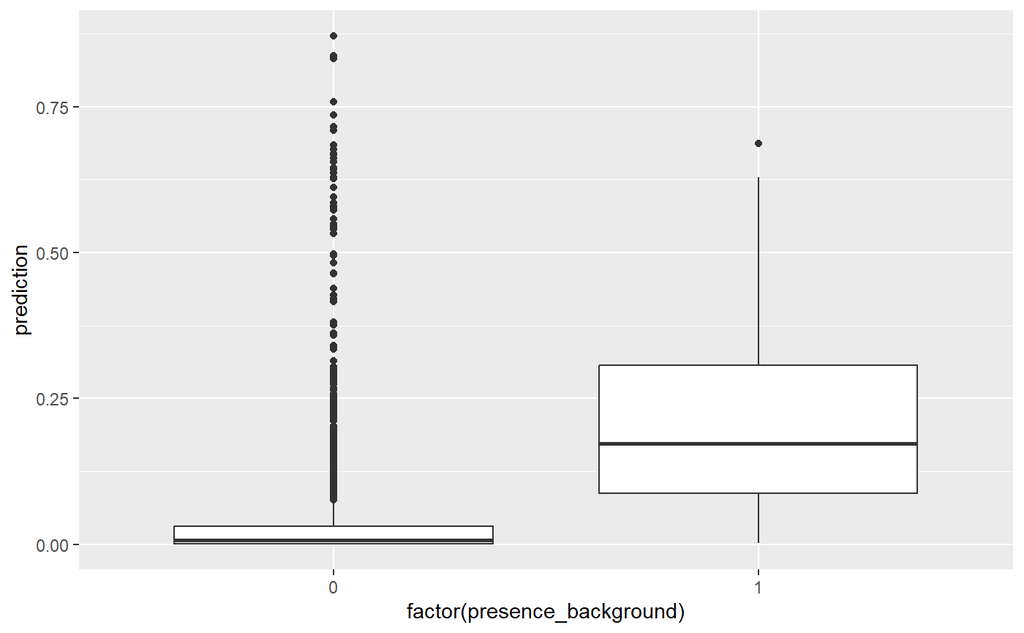

```r
rf_predictions %>%
  ggplot() +
  geom_boxplot(aes(x = factor(presence_background), y = prediction))
```

10. How do the distributions compare between test presence and test background points?  
    The test presence points (for which presence_background = 1) have a higher median than the test background points (for which presence_background = 0) do, and also a wider IQR.
11. What are the two medians? Do they surprise you?  
    The median for test presence points is somewhere between 0.125 and 0.25 percent chance to find a sloth at that point in the data that was held out for testing, while the median for test background points is about 0%. (It can be greater than 0 because some of the background points may have actually contained sloths.) This difference in medians is expected, and in the correct direction, so that is good. We would expect 0 probability to find sloths in background points, and some probability to find sloths in presence points.

One downside of using randomly chosen background points is that we very likely chose some locations where sloths actually do live. This overlap makes our model more conservative and less likely to predict a presence. However, it can still give us useful information about where occurrences are most likely. Let’s visualize that.

### 1.7.2 Plotting the predictions across the landscape

Now we’re going to use a different predict function, this time from the raster package, but it also applies a model to new data. In this case, the new data are in the form of a raster stack and the predictions are returned as a raster layer.

```r
predictions_rf_model <- predict(predictors, rf_model, ext = extent(predictors))
```

We can plot that layer. We can also plot the occurrence and background points on top of it to assess whether it seems reasonable.

```r
if (!dir.exists("BV_figures")){
  dir.create("BV_figures")
}

# We set the location to save the plot
png(filename = 'BV_figures/BV_predictions_rf.png',pointsize=5, width=2800, height=2000, res=800)
# Then we make the plot
plot(predictions_rf_model, main = 'Random Forest predicted probabilities')
points(background, col = 'red', pch = 16, cex = 0.2)
points(occurrence, col = 'black', pch = 16, cex = 0.2)
```

12. Look in the new BV_figures folder at the plot we just made. How do the predicted probabilities compare to the actual occurrences?  
    The areas with high predicted probability of observing sloths (the green areas) coincide with the actual occurrences of sloths (the black points), but there are green areas where there haven’t been sloth observations which is a promising sign that it isn’t overfit.

Sometimes to get a better sense of the distribution of probabilities when most probabilities are very low, it’s helpful to use a complementary log log (cloglog) transformation. Let’s see how that affects the map:

```r
# transforming probabilities
predictions_rf_cloglog <- log(-log(1 - predictions_rf_model))
# We set the location to save the plot
png(filename = 'BV_figures/BV_predictions_rf_cloglog.png',pointsize=5, width=2800, height=2000, res=800)
# Then we make the plot
plot(predictions_rf_cloglog, main='Random Forest cloglog')
points(background, col='red', pch = 16,cex=.2)
points(occurrence, col='black', pch = 16,cex=.2)
```

13. Look at the new BV_predictions_rf_cloglog.png file. Based on this, where are some locations that the model predicts are suitable for sloths outside of their known range (outside of the locations where the occurrence points are)?  
    There’s a patch of high probability for sloth occurrence (with no black points inside, i.e. outside of the sloths’ known range) at about (8N, 60W). There are also some green patches in the bottom right corner of the map.

## 1.8 Fitting a Maximum Entropy Model

Now let’s try a different machine learning algorithm. This MaxEnt algorithm is the most popular algorithm for species distribution modeling.

ENMevaluate is a function in the ENMeval package that both fits and evaluates many different species distribution models, including MaxEnt models. We will be running the R version of MaxEnt, which was named maxnet (I know- it’s confusing!). The model will be run and tested on different subsets of the data. Below I used the “block” option which does this by spatially partitioning the data. Then we have to set tuning parameters. The tuning parameters are:

- fc for feature classes to include in the models
- rm for regularization multiplier, which penalizes the model for being too complex (lower regularization multipliers allow more complexity)
14. Skim through these descriptions of the (feature classes)[https://drive.google.com/file/d/1QHvnALCavsdbtsJ3KHnCxhBLgpQqoX0P/view?usp=sharing]. What is the difference between a threshold and a hinge feature?  
    For threshold features, all responses on one side of the knot (the x-axis threshold) are the same value, whereas for hinge features, the responses increase or decrease linearly on one side of the knot.

You can learn more about all of that (here)[https://jamiemkass.github.io/ENMeval/articles/ENMeval-2.0-vignette.html#eval]

Let’s fit a very simple set of models so they are easier to interpret (this may take a few minutes):

```r
# I was having trouble getting the ENMevaluate function to recognize that Biome was a factor
# when I used the raster stack as input so instead we'll use data frames of environmental values
occurrence_maxent <- cbind(occurrence, raster::extract(predictors, occurrence)) %>%
  mutate(Biome = as.factor(Biome))
background_maxent <- cbind(background, raster::extract(predictors, background)) %>%
  mutate(Biome = as.factor(Biome))

# Saves a very complex object with lots of data about the fitted models
eval_maxent_linear <- ENMevaluate(occs = occurrence_maxent,  # occ = occurrences
                      bg = background_maxent,  # bg = background points
                      algorithm = 'maxnet',  # we are using the R version of MaxEnt
                      partitions = 'block',  # the model training is done using spatial blocks
                      tune.args = list(fc = "L", rm = 1:2))  # restricting to linear models
```

```
Package ecospat is not installed, so Continuous Boyce Index (CBI) cannot be calculated.
*** Running initial checks... ***

* Variable values were input along with coordinates and not as raster data, so no raster predictions can be generated and AICc is calculated with background data for Maxent models.
* Removed 45 occurrence points with NA predictor variable values.
* Removed 270 background points with NA predictor variable values.
* Assigning variable Biome to categorical ...
* Model evaluations with spatial block (4-fold) cross validation and lat_lon orientation...

*** Running ENMeval v2.0.4 with maxnet from maxnet package v0.1.4 ***
```

```
ENMevaluate completed in 16 minutes 42.3 seconds.
```

```r
                      # fc = c("L","LQ","LQH","H") would mean to fit models with:
                      # linear, linear+quadratic, linear+quadratic+hinge, and only hinge features
```

### 1.8.1 MaxEnt modeling results

```r
# Overall results
res <- eval.results(eval_maxent_linear)

res
```

| fc | rm | tune.args | auc.train | cbi.train | auc.diff.avg | auc.diff.sd | auc.val.avg | auc.val.sd | cbi.val.avg | cbi.val.sd | or.10p.avg | or.10p.sd | or.mtp.avg | or.mtp.sd | AICc | delta.AICc | w.AIC | ncoef |
| --- | --- | --- | --- | --- | --- | --- | --- | --- | --- | --- | --- | --- | --- | --- | --- | --- | --- | --- |
| L | 1 | fc.L_rm.1 | 0.7954422 | NA | 0.10463624 | 0.07925784 | 0.6899341 | 0.07685396 | NA | NA | 0.2474066 | 0.1442724 | 0.06746032 | 0.08028567 | 8802.717 | 0.00000 | 9.999217e-01 | 12 |
| L | 2 | fc.L_rm.2 | 0.7912692 | NA | 0.09552833 | 0.07168888 | 0.6896500 | 0.07490211 | NA | NA | 0.2375172 | 0.1583256 | 0.04365079 | 0.07230503 | 8821.627 | 18.91055 | 7.826936e-05 | 12 |

Above you’ll see two rows, one for each model that the function fit.

15. What are the two values in the regularization multiplier (rm) column? Which row has the more complicated model?  
    The regularization multiplier values are 1 and 2. Row 1 has the lower RM value, meaning it has a smaller penalty for model complexity and therefore a more complicated model.

The auc.train column tells us about a value called AUC or (Area Under the Curve)[https://en.wikipedia.org/wiki/Receiver_operating_characteristic#Area_under_the_curve], which refers to a curve with false positive rate on the x-axis and the true positive rate on the y-axis. We won’t get into the details of this, but the important thing to remember is that a higher AUC value means the model is better at predicting outcomes. The closer it is to 1, the better the model. Values of 0.8 and above are generally considered to have good predictive power.

16. What are the two AUC values here? Based on that, which is the better model?  
    The AUC values are 0.7954422 and 0.7912692, suggesting that the model in the first row is the better model, as it has the higher AUC.

Another way to assess model fit is to look at the AIC or (Akaike Information Criterion)[https://en.wikipedia.org/wiki/Akaike_information_criterion]. This measure gives a sense of both a model’s simplicity and its predictive power. Lower values are considered better. When comparing models, we often use a threshold difference of 2 or more in AIC values to decide whether two models are significantly different in quality.

17. Scroll over to the AICc column. Based on those values, which is the better model? How different are they?  
    The AICc values are 8802.717 and 8821.627, suggesting that the model in the first row is better, since it has the lower AICc value. The models are significantly different in quality because the AICc values have a difference of greater than 2.

To select one model, let’s choose the model with the lowest AIC value using eval.models to get a list of the two models and [[opt.aicc$tune.args]] to extract that one:

```r
opt.aicc <- res %>% filter(delta.AICc == 0)
# whichever model has the lowest AICc will be the model that is used for comparison
# when calculating the delta.AICc (change in AIC between models)

mod.aicc <- eval.models(eval_maxent_linear)[[opt.aicc$tune.args]]

# We use $betas to get the coefficient estimates from the model
mod.aicc$betas
```

```
          AnnualPrecip   PrecipWettestQuarter    PrecipDriestQuarter    MaxTempWarmestMonth        TempAnnualRange
           0.002513128           -0.003465601           -0.005871384           -0.525766278           -0.095516456
MeanTempWettestQuarter   categorical(Biome):1   categorical(Biome):2   categorical(Biome):3   categorical(Biome):7
           0.496235270           -0.077687421            0.308172897            0.731698972           -0.275130752
 categorical(Biome):13  categorical(Biome):10
           0.731030774           -2.254719410
```

These beta values show estimates of the coefficients in the model.

18. Which of the continuous variables (not the biomes) has the coefficient with the largest absolute value? What direction is the effect (does an increase in that variable increase the probability of finding sloths or decrease it)?  
    MaxTempWarmestMonth has the coefficient with the largest absolute value. Its coefficient is in the negative direction, suggesting that an increase in MaxTempWarmestMonth decreases the probability of finding sloths.

Now let’s plot the effects of the variables:

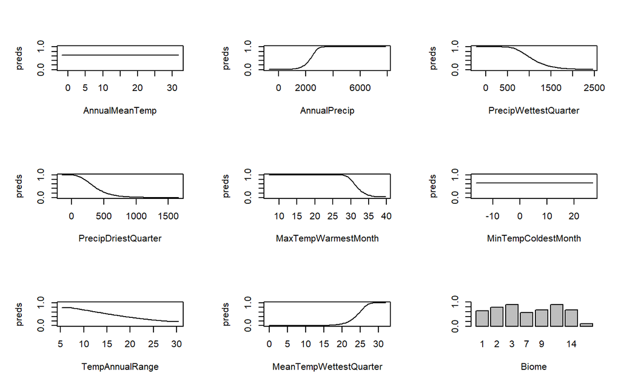

```r
plot(mod.aicc, type = "cloglog")
```

19. Based on these plots, how does mean temperature in the wettest quarter of the year affect the probability of sloth presence?  
    The higher the mean temperature in the wettest quarter of the year, the higher the probability of sloth presence. According to the plot, the probability of finding a sloth is 100% at MeanTempWettestQuarter of 30 degrees or above.

### 1.8.2 Assessing model performance with the test data

*Note:* By default, model predictions from maxnet are cloglog transformed probabilities.

```r
maxent_presence_predict <- predict(object = mod.aicc,
                                   newdata = presence_test) %>%
                                  data.frame() %>%  # make predictions into a data frame
                                  mutate(presence_background = 1)  # add a column

maxent_background_predict <- predict(object = mod.aicc,
                                   newdata = background_test) %>%
                                  data.frame() %>%
                                  mutate(presence_background = 0)

# combine the two data frames
model_predictions <- rbind(maxent_presence_predict, maxent_background_predict)

# rename the first column for plotting
names(model_predictions)[1] <- "prediction_cloglog"

# transform the cloglog output back to probabilities
model_predictions$prediction_prob <- 1 - exp(-exp(model_predictions$prediction_cloglog))
```

20. Use the head() function to look at the model_predictions data frame:

```r
head(model_predictions)
```

|  | prediction_cloglog | presence_background | prediction_prob |
| --- | --- | --- | --- |
| 12 | -7.357988 | 1 | 6.372768e-04 |
| 2 | -8.059114 | 1 | 3.161567e-04 |
| 3 | -6.833241 | 1 | 1.076781e-03 |
| 4 | -7.144518 | 1 | 7.888672e-04 |
| 5 | -9.447638 | 1 | 7.887253e-05 |
| 6 | -7.789398 | 1 | 4.140165e-04 |

21. Now use boxplots to compare the distributions of prediction_prob between presence and background points. Remember to use factor(presence_background):

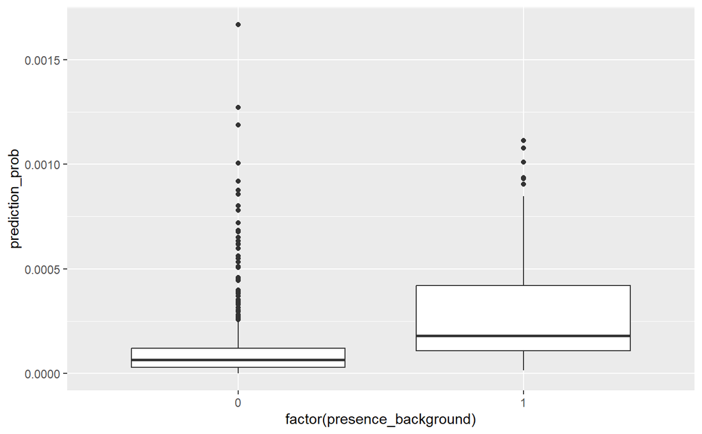

```r
model_predictions %>%
  ggplot() +
  geom_boxplot(aes(x = factor(presence_background), y = prediction_prob))
```

22. How does this compare to the Random Forest model predictions?  
    Compared to the Random Forest model predictions (problem 9), the presence points have much lower predicted probabilities- almost equal to 0. NOTE: the transform in MaxEnt is not actually cloglog, so the “untransformed” predicted probabilities are lower than they should be. However, the proportions of the probabilities have been preserved. These proportions look similar to the boxplot from problem 9, although the data for the presence and background are more similar than they should be. We want the presence and background to be as different as possible. Background =/= absence, so there should be variability (hence the outliers), but the background median should be lower. For the presence, the median should be higher and there should be less variability. This boxplot doesn’t necessarily suggest that the MaxEnt model is worse than the Random Forest model.

### 1.8.3 Plotting predictions across the landscape

Now we can plot the cloglog scores:

```r
predictions_maxent_model <- raster::predict(predictors,
                                        mod.aicc,
                                        ext = raster::extent(predictors))


png(filename = 'BV_figures/BV_predictions_maxent.png',pointsize=5, width=2800, height=2000, res=800)
plot(predictions_maxent_model, main='maximum entropy cloglog')
points(background, col='red', pch = 16,cex=.2)
points(occurrence, col='black', pch = 16,cex=.2)
```

23. Look at the BV_predictions_maxent.png file. How does this compare to the Random Forest cloglog map?  
    Compared to BV_predictions_rf_cloglog.png, the cloglog scores in the MaxEnt model are generally closer together. This is because the MaxEnt model was fit with only linear models (line 411); if it weren’t constricted to a linear model, the values might be more dissimilar, as they are in the Random Forest model. (The relationship between two variables is easier to interpret in linear models than in more complicated models.)

```r
evaluate(presence_test, background_test, mod.aicc)
```

```
class          : ModelEvaluation
n presences    : 99
n absences     : 1940
AUC            : 0.8098797
cor            : 0.2188638
max TPR+TNR at : -9.204197
```

```r
evaluate(presence_test, background_test, rf_model)
```

```
class          : ModelEvaluation
n presences    : 99
n absences     : 1940
AUC            : 0.9025825
cor            : 0.3467475
max TPR+TNR at : 0.0562
```

The last output: recommended threshold. The threshold at which the model gives the best rates of identification (true positive and true negative rates are optimized) based on the test data. You can use these thresholds for code like in the last part of this in-class activity when calculating the amount of suitable land for the sloths.

## 1.9 Calculating area of regions above a suitability threshold

One thing we may want to do once we have these maps is quantify how much land is above a certain threshold of suitability. This is especially useful for comparing current and future species ranges. Below I give an example of how to do this with a threshold score of -9 (getting the area in km^2 of all grid squares with that score or higher).

The approach below is modified from source code found at: Otto, S. (2022): Caucasian Spiders. A faunistic database on the spiders of the Caucasus. Version 02.2022 Internet: https://caucasus-spiders.info/

```r
# Area calculation

# save and then modify full raster
predictions_neg9 <- predictions_maxent_model
predictions_neg9[predictions_neg9 <= -9] <- NA

# get sizes of all cells with suitability over -9
cell_size <- area(predictions_neg9,
                  na.rm = TRUE,
                  weights = FALSE)

# delete any NAs from vector of all raster cells
cell_size <- cell_size[!is.na(cell_size)]

# compute area [km2] of all cells in prediction_over50
suitable_area_neg9 <- length(cell_size)*mean(cell_size)

suitable_area_neg9
```

```
[1] 2369263
```

23. Try doing the same thing with a threshold score of -10 instead:

```r
# Area calculation

# save and then modify full raster
predictions_neg10 <- predictions_maxent_model
predictions_neg10[predictions_neg10 <= -10] <- NA

# get sizes of all cells with suitability over -10
cell_size <- area(predictions_neg10,
                  na.rm = TRUE,
                  weights = FALSE)

# delete any NAs from vector of all raster cells
cell_size <- cell_size[!is.na(cell_size)]

# compute area [km2] of all cells in prediction_over50
suitable_area_neg10 <- length(cell_size)*mean(cell_size)

suitable_area_neg10
```

```
[1] 6908038
```

Area calculation for Random Forest model, using the threshold of 0.0562, in order to compare the area predicted by each model to be suitable habitat for sloths:

```r
# Area calculation

# save and then modify full raster
predictions_rf_0.0562 <- predictions_rf_model
predictions_rf_0.0562[predictions_rf_0.0562 <= 0.0562] <- NA

# get sizes of all cells with suitability over 0.0562
cell_size <- area(predictions_rf_0.0562,
                  na.rm = TRUE,
                  weights = FALSE)

# delete any NAs from vector of all raster cells
cell_size <- cell_size[!is.na(cell_size)]

# compute area [km2] of all cells in prediction_over50
suitable_area_rf_0.0562 <- length(cell_size)*mean(cell_size)

suitable_area_rf_0.0562
```

```
[1] 1891566
```

The Random Forest model predicts that an area of 1891566 km^2 is suitable habitat, while the MaxEnt model at threshold = -9 predicted that an area of 2369263 km^2 was suitable.